# ExtraaLearn Project

## Building a Random Forest model

### **Random Forest**

- **Random Forest is a bagging algorithm where the base models are Decision Trees.** Samples are taken from the training data and on each sample, a decision tree makes a prediction.
- The results from all the **decision trees** are combined and the final prediction is made using **voting** (for classification problems) or **averaging** (for regression problems).**

```python
# Fitting the Random Forest classifier on the training data
# rf_estimator = RandomForestClassifier(class_weight = {0: 0.17, 1: 0.83}, random_state = 1)

# rf_estimator.fit(X_train, y_train)

# Fitting the Random Forest classifier on the training data
rf_estimator = RandomForestClassifier(class_weight = {'Not Converted': 0.17, 'Converted': 0.83}, random_state = 1)

# df.fillna(0, inplace=True)
X_train.fillna(0, inplace=True)
X_test.fillna(0, inplace=True)
rf_estimator.fit(X_train, y_train)
```

```
RandomForestClassifier(class_weight={'Converted': 0.83, 'Not Converted': 0.17},
                       random_state=1)
```

```
               precision    recall  f1-score   support

    Converted       1.00      1.00      1.00       964
Not Converted       1.00      1.00      1.00      2264

     accuracy                           1.00      3228
    macro avg       1.00      1.00      1.00      3228
 weighted avg       1.00      1.00      1.00      3228
```

[figure not shown]

```python
# Checking performance on the training data
y_pred_train_rf = rf_estimator.predict(X_train)

metrics_score(y_train, y_pred_train_rf)
```

**Observation:**

- For all the metrics in the training dataset, the Random Forest gives a 100% score.

```
               precision    recall  f1-score   support

    Converted       0.76      0.69      0.72       413
Not Converted       0.87      0.91      0.89       971

     accuracy                           0.84      1384
    macro avg       0.82      0.80      0.81      1384
 weighted avg       0.84      0.84      0.84      1384
```

[figure not shown]

```python
# Checking performance on the testing data
y_pred_test_rf = rf_estimator.predict(X_test)

metrics_score(y_test, y_pred_test_rf)
```

**Observations:**

- The Random Forest classifier **seems to be overfitting the training data**. The recall on the training data is 1, while the recall on the test data is only 0.69 for class 1 (Converted).
- Precision has gone up to 0.76 for the test data comparing to 0.66 in the Decision Tree result.

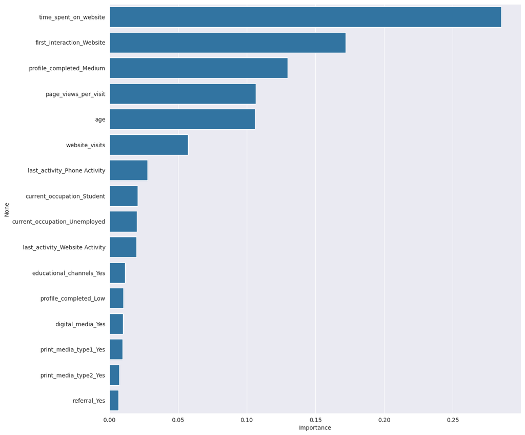

```python
importances = rf_estimator.feature_importances_
columns = X.columns
importance_df = pd.DataFrame(importances, index = columns, columns = ['Importance']).sort_values(by = 'Importance', ascending = False)
plt.figure(figsize = (13, 13))
sns.barplot(data = importance_df, x = importance_df.Importance, y = importance_df.index)
```

**Observations:**

Based on the feature importance plot generated for the Random Forest model, we can make several observations:

Top Important Features:

Profile Completion:

Other Important Features:

- 'first_interaction_Website' is also found to have a significant influence, suggesting that leads who initially interact with the company through the website are more prone to conversion.

## Do we need to prune the tree?

- We generally don't prune individual trees within a Random Forest.
- The ensemble nature of Random Forest inherently handles overfitting.
- Instead of pruning, we can try to optimize hyperparameters like max_depth, min_samples_split, and n_estimators to control the complexity and prevent overfitting.
- We can use GridSearchCV to find the best hyperparameters for the Random Forest model.

```python
# Choose the type of classifier.
# Update class_weight to use actual class labels
rf_estimator_tuned = RandomForestClassifier(class_weight={'Converted': 0.17, 'Not Converted': 0.83}, random_state=1)

# Grid of parameters to choose from
# Update max_features to use 'sqrt' instead of 'auto'
params_rf = {
    "n_estimators": [100, 250, 500],
    "min_samples_leaf": np.arange(1, 4, 1),
    "max_features": [0.7, 0.9, 'sqrt'],  # Changed 'auto' to 'sqrt'
}

# Type of scoring used to compare parameter combinations - recall score for class 1
# Assuming 'Converted' is the positive label
scorer = metrics.make_scorer(recall_score, pos_label='Converted')

# Run the grid search
grid_obj = GridSearchCV(rf_estimator_tuned, params_rf, scoring=scorer, cv=5)

grid_obj = grid_obj.fit(X_train, y_train)

# Set the classifier to the best combination of parameters
rf_estimator_tuned = grid_obj.best_estimator_
```

```python
rf_estimator_tuned.fit(X_train, y_train)
```

```
RandomForestClassifier(class_weight={'Converted': 0.17, 'Not Converted': 0.83},
                       max_features=0.7, random_state=1)
```

```
               precision    recall  f1-score   support

    Converted       0.72      0.74      0.73       413
Not Converted       0.89      0.88      0.88       971

     accuracy                           0.84      1384
    macro avg       0.80      0.81      0.81      1384
 weighted avg       0.84      0.84      0.84      1384
```

[figure not shown]

```python
# Checking performance on the test data
y_pred_test_rf_tuned = rf_estimator_tuned.predict(X_test)

metrics_score(y_test, y_pred_test_rf_tuned)
```

```
               precision    recall  f1-score   support

    Converted       1.00      1.00      1.00       964
Not Converted       1.00      1.00      1.00      2264

     accuracy                           1.00      3228
    macro avg       1.00      1.00      1.00      3228
 weighted avg       1.00      1.00      1.00      3228
```

[figure not shown]

```python
# Checking performance on the training data
y_pred_train_rf_tuned = rf_estimator_tuned.predict(X_train)

metrics_score(y_train, y_pred_train_rf_tuned)
```

**Observations:**

- The tuned model likely shows an improvement in the recall score of 0.74 vs 0.69 for the "Converted" class, especially compared to the un-tuned Random Forest model.
- This means the model is now better at identifying true positive "Converted" leads, which was our primary objective.
- The tuned model is also slightly overfitting the training dataset, but **it shows a good performance on the test dataset.**
- **The recall for class 1 has improved with a small decrease in precision**.
- **This model is the best-performing one among all the models so far,** and is giving us good precision and recall scores on the test dataset.

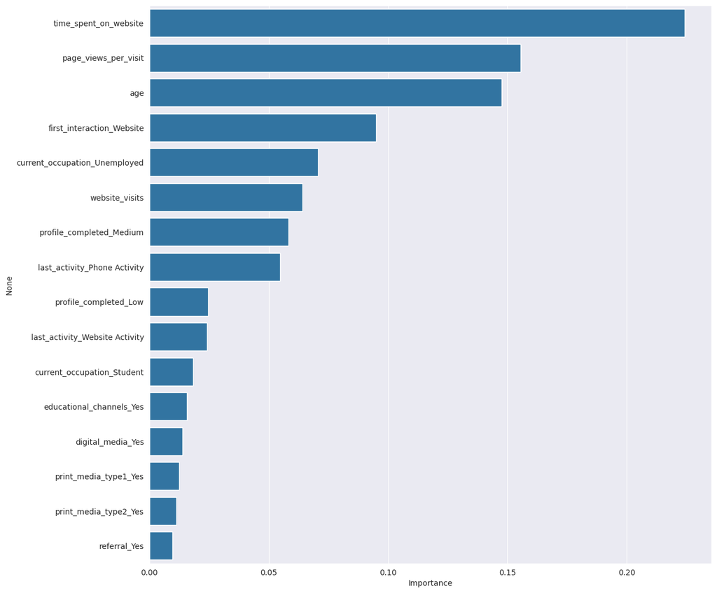

```python
# Plotting feature importance
importances = rf_estimator_tuned.feature_importances_
columns = X.columns
importance_df = pd.DataFrame(importances, index = columns, columns = ['Importance']).sort_values(by = 'Importance', ascending = False)
plt.figure(figsize = (13, 13))
sns.barplot(data = importance_df, x = importance_df.Importance, y = importance_df.index)
```

**Observations:**

## Actionable Insights and Recommendations

Based on the analysis and model performance, we have summarized actionable insights and recommendations:

(1).Focus on Website Engagement:

- The model highlights that website engagement metrics like `website_visits`, `page_views_per_visit`, and `time_spent_on_website` are the strong predictors of lead conversion.
- Recommendation:
  - Optimize the website for better user experience by improving content quality, and encouraging more interactions from potential leads.
  - Create engaging landing pages by providing valuable content, and implementing interactive and feedback elements.
  - Prioritize website optimization as a key strategy for attracting and converting leads.

(2). Enforce Profile Completion:

- Leads with more complete profiles (higher and medium 'profile_completed') are more likely to convert.
- Recommendation:
  - Encourage leads to complete their profile during the onboarding process.
  - This could be achieved through incentives or gamification techniques.

(3). Further Analysis:

- Investigate the characteristics of leads that are classified as 'Not Converted' but have high potential for conversion.
- Recommendation:
  - Analyze the reasons why these leads are not converted, and explore potential actions to address the issues.

(4). Business Insights:

- The models provide valuable insights for improving lead conversion strategies for the marketing teams.
- We can prioritize leads with high website engagement, profile completion, and activity in email interactions.
- We can also tailor marketing campaigns to encourage website engagement and profile completion, thereby increasing the likelihood of conversion.

# Summary and Comments

Comparison on Decision Tree and Random Forest

- The performane such as accuracy score of the Random Forest model is shown to be higher than that of the Decision Tree model, indicating that the ensemble approach has improved the overall predictive ability of the model.
- This is expected, as Random Forest generally provides more robust and accurate predictions compared to a single decision tree.

Comments on GridSearchCV Results

- The GridSearchCV process has helped us find a better set of hyperparameters for both the decision tree and random forest model, improving the model's performance on the test data (compared to the previous un-tuned model).
- GridSearchCV helped to reduce overfitting by finding a balance between the model's complexity (e.g., maximum depth) and its performance on the validation set during cross-validation.
- This is important to ensure that the model generalizes better to unseen data and avoids simply memorizing the training dataset.

Factors that drive conversion - time_spent_on_website, first_interaction_Website, profile_completed, and age.

- 'time_spent_on_website': This indicates that leads who spend more time on the website are more likely to convert. This could be due to the fact that they are more interested in the course.
- profile_completed': Leads with a high percentage of profile completed are also more likely to convert.
- 'first_interaction_Website': This suggests that leads who first interacted with the company through the website are more likely to convert.
- 'age' : It suggests that older customers are more likely to become paid customers, potentially due to higher income or more established careers.